# Criminal_Sentencing

Devyani Srivastava

2022-11-15

*Algorithmic Bias in Criminal Sentencing*

Following is an example of data science in Journalism. The purpose of the project is to shed light on how the criminal sentencing by **Correctional Offender Management Profiling for Alternative Sanctions(COMPAS)** is racially biased. The purpose of Journalism is to give voice and by use of such projects it exactly does that.

```r
#loading libraries
library(tidyverse)
```

```r
library(readr)
library(dplyr)
library(ggplot2)
library(grid)
library(gridExtra)
library(caTools)
library(pROC)
library(caret)
library(psych)
```

For the purpose of the project I have taken the dataset from **ProPublica of criminal justice records from Broward County, Florida** and created own risk assessment model.

```r
crime<-read.csv("https://raw.githubusercontent.com/propublica/compas-analysis/master/compas-scores-two-years.csv",header = TRUE)

head(crime)
```

```
##   id               name  first        last compas_screening_date  sex
## 1  1   miguel hernandez miguel   hernandez            2013-08-14 Male
## 2  3        kevon dixon  kevon       dixon            2013-01-27 Male
## 3  4           ed philo     ed       philo            2013-04-14 Male
## 4  5        marcu brown  marcu       brown            2013-01-13 Male
## 5  6 bouthy pierrelouis bouthy pierrelouis            2013-03-26 Male
## 6  7       marsha miles marsha       miles            2013-11-30 Male
##          dob age         age_cat             race juv_fel_count decile_score
## 1 1947-04-18  69 Greater than 45            Other             0            1
## 2 1982-01-22  34         25 - 45 African-American             0            3
## 3 1991-05-14  24    Less than 25 African-American             0            4
## 4 1993-01-21  23    Less than 25 African-American             0            8
## 5 1973-01-22  43         25 - 45            Other             0            1
## 6 1971-08-22  44         25 - 45            Other             0            1
##   juv_misd_count juv_other_count priors_count days_b_screening_arrest
```

[output cut: 69 more lines]

**Data Cleaning** for the final model i have selected features most relevant for analysis that includes Sex,Race,Prior count, Juvenile felony Count, Juvenile misdemeanor count, Juvenile other count, charge degree, and two year recidivism. Age at charge was calculated from difference of their date of birth and date when they went to jail. The age was categorized to five categories and length of stay at jail was counted by subtracting c_jail_out and c_jail_in. All the NA values were dropped.

```r
clean<-crime%>%select("sex","race","priors_count","juv_fel_count","juv_misd_count","juv_other_count","c_charge_degree","c_jail_out","c_jail_in","dob","age","two_year_recid")%>%mutate(age.at.charge=as.Date(c_jail_in)-as.Date(dob),length_of_stay=as.Date(c_jail_out) - as.Date(c_jail_in))%>%na.omit()
clean<-clean%>%select(-c("c_jail_out","c_jail_in","dob"))
```

```r
for(i in (1:range(nrow(clean)))){
  if (clean$age[i]>16 & clean$age[i]<25){clean$age[i]="[17,24]"}
  if (clean$age[i]>24 & clean$age[i]<32){clean$age[i]="(24,31]"}
  if (clean$age[i]>31 & clean$age[i]<43){clean$age[i]="(31,42]"}
  if (clean$age[i]>42 & clean$age[i]<81){clean$age[i]="(42,80]"}
  if(clean$age[i]>80){clean$age[i]="older"}
}
clean<-clean%>%rename(age.cat=age)
```

**Exploratory Data Analysis**

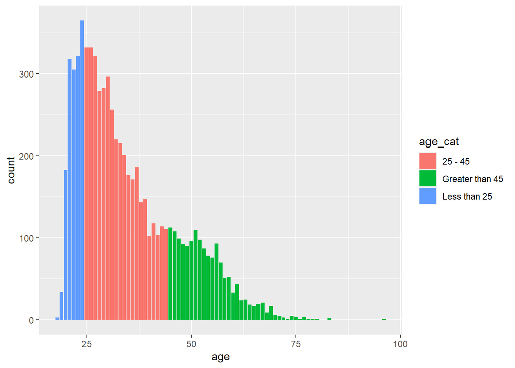

```r
crime%>%ggplot(mapping = aes(x = age, fill=age_cat)) + geom_bar()
```

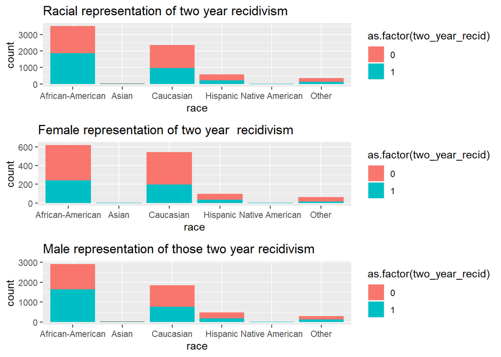

```r
c1<-clean %>%ggplot(mapping = aes(x = race, fill=as.factor(two_year_recid))) + geom_bar()+ggtitle("Racial representation of two year recidivism")

c2<-clean%>%filter(sex=="Female")%>%ggplot(aes(x=race,fill=as.factor(two_year_recid)))+geom_bar()+ggtitle("Female representation of two year  recidivism")

c3<-clean%>%filter(sex=="Male")%>%ggplot(aes(x=race,fill=as.factor(two_year_recid)))+geom_bar()+ggtitle("Male representation of those two year recidivism")

grid.arrange(c1, c2,c3, ncol = 1,nrow=3)
```

Above graphs represents the analysis of two year recidivism and it is can be clearly concluded that overall more African american have recidivism score than any other races and so is true while doing gender wise analysis. Although difference between second most and first race i.e. Caucasian and African american is less for females when compare to males.

**Creating correlation matrix**

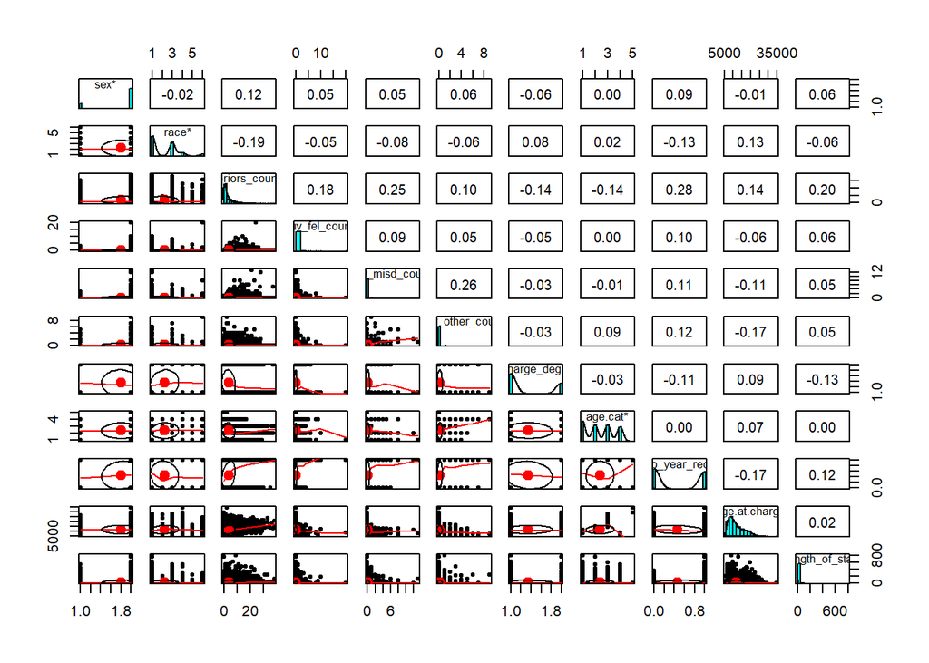

```r
pairs.panels(clean)
```

From the correlation matrix we can implicate that the features does not have any significant correlation which is good sign for our model

**Creating training and testing datasets** Divide train and test in 80-20 ratio

```r
index.doc<-sample(x=nrow(crime), size=0.80*nrow(crime))
train_crime<-clean[index.doc,]
test_crime<-clean[-index.doc,]
```

**Logistic Regression Model** Output variable is taken as two year recidivism score

```r
crime_glm<-glm(train_crime$two_year_recid~ .,data=train_crime,family = binomial)
summary(crime_glm)
```

```
##
## Call:
## glm(formula = train_crime$two_year_recid ~ ., family = binomial,
##     data = train_crime)
##
## Deviance Residuals:
##     Min       1Q   Median       3Q      Max
## -2.9114  -0.9875  -0.6416   1.0810   2.1244
##
## Coefficients:
##                       Estimate Std. Error z value Pr(>|z|)
## (Intercept)          1.634e-01  2.215e-01   0.738 0.460757
## sexMale              2.856e-01  7.533e-02   3.791 0.000150 ***
## raceAsian           -8.083e-01  4.854e-01  -1.665 0.095897 .
## raceCaucasian       -3.381e-03  6.677e-02  -0.051 0.959620
## raceHispanic        -1.196e-01  1.118e-01  -1.070 0.284609
## raceNative American  2.734e-01  6.203e-01   0.441 0.659383
## raceOther           -1.327e-01  1.377e-01  -0.964 0.335263
## priors_count         1.494e-01  8.564e-03  17.445  < 2e-16 ***
## juv_fel_count        2.129e-01  1.033e-01   2.061 0.039300 *
## juv_misd_count      -8.250e-03  8.179e-02  -0.101 0.919658
## juv_other_count      2.461e-01  7.501e-02   3.281 0.001035 **
## c_charge_degreeM    -1.716e-01  6.311e-02  -2.720 0.006535 **
## age.cat(31,42]      -2.156e-01  1.039e-01  -2.075 0.038021 *
## age.cat(42,80]       3.019e-02  2.060e-01   0.147 0.883462
## age.cat[17,24]       3.432e-01  9.292e-02   3.693 0.000221 ***
## age.catolder         1.413e+01  1.970e+02   0.072 0.942810
## age.at.charge       -9.262e-05  2.179e-05  -4.251 2.12e-05 ***
## length_of_stay       2.861e-03  6.770e-04   4.226 2.37e-05 ***
## ---
## Signif. codes:  0 '***' 0.001 '**' 0.01 '*' 0.05 '.' 0.1 ' ' 1
##
## (Dispersion parameter for binomial family taken to be 1)
##
##     Null deviance: 7613.2  on 5515  degrees of freedom
## Residual deviance: 6725.9  on 5498  degrees of freedom
##   (255 observations deleted due to missingness)
## AIC: 6761.9
##
## Number of Fisher Scoring iterations: 10
```

Predicting the recidivism score using model on testing dataset

```r
predict_crime<-predict(crime_glm,test_crime,type='response')
```

using the sigmoid concept

```r
predicted<-ifelse(predict_crime>0.50,1,0)
```

**Confusion Matrix**

```r
confusionMatrix(as.factor(test_crime$two_year_recid),as.factor(predicted))
```

```
## Confusion Matrix and Statistics
##
##           Reference
## Prediction   0   1
##          0 550 188
##          1 273 380
##
##                Accuracy : 0.6686
##                  95% CI : (0.6432, 0.6933)
##     No Information Rate : 0.5917
##     P-Value [Acc > NIR] : 2.080e-09
##
##                   Kappa : 0.3297
##
##  Mcnemar's Test P-Value : 9.143e-05
##
##             Sensitivity : 0.6683
##             Specificity : 0.6690
##          Pos Pred Value : 0.7453
##          Neg Pred Value : 0.5819
##              Prevalence : 0.5917
##          Detection Rate : 0.3954
##    Detection Prevalence : 0.5306
##       Balanced Accuracy : 0.6687
##
##        'Positive' Class : 0
##
```

Sensitivity or True positive rate which is true positive rate the percentage of individuals the model correctly predicted . Here Sensistivity is low that means that model did not correctly predicted the recidivism score i.e. people who should be have high recidivism shouldnt have low recidivism score.

Specificity or true negative rate the percentage of individuals the model correctly predicted would have low risk. For the above model the specificity is low i.e. people who have low recidivism shouldnt have low recidivism score.

The model also have low accuracy

**ROC Curve**

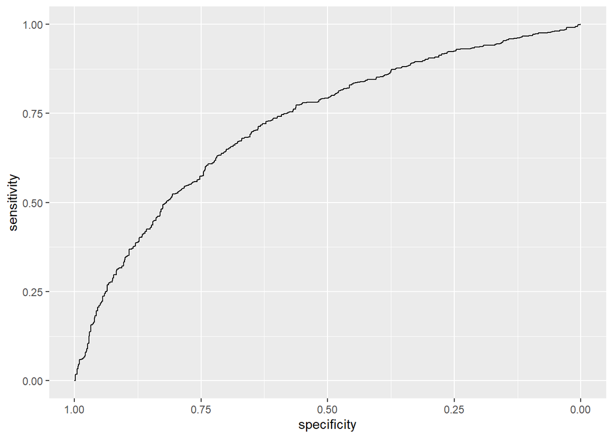

```r
ggroc(roc(test_crime$two_year_recid,predict_crime))
```

The ROC Curve of our classification model is bad. A poor classifier will not properly distinguish between the two classes.

**Algorithmic Bias**

**Conclusion**

The model is clearly biased because it takes race and sex as one of it’s features. As there is lot of history behind wrongfully conviction and supression of one race by another having such factors in training the model is ethically wrong. Also, the evaluation of model suggests that sizeable people who have low risk score should have high risk score and visa a versa. With such a model in implementation in real life people can be wrongfully convicted and those who should be convicted just because they belong to certain race are out of consideration.